# task3-biosensor-cleaning

Nursima Çalık

2026-09-30

## Upload the Data

```r
electrode <- read.csv("Data/electrodes.csv")
measurements <- read.csv("Data/measurements.csv")
```

# Examine the Data and Make Corrections

The datasets were examined. Duplicates were removed. Ordering based on electrode ID was made and redundant words were deleted. Gaps and capitals mistakes were corrected. Some response had nA unit so all units were arranged as uA. Units were not only changed but also responses were turned to uA. For this changing , “ifelse” function was used. Also most of change were made by “mutate” function. [1-6]

```r
library(dplyr)
library(stringr)
library(tidyverse)
dim(electrode)
```

```
## [1] 25  5
```

```r
str(electrode)
```

```
## 'data.frame':    25 obs. of  5 variables:
##  $ electrode_id     : chr  "E001" "E002" "E003" "E004" ...
##  $ coating          : chr  "Standard" "standard" "Standard " "Standard" ...
##  $ storage_days     : chr  "0" "1" "3" "7" ...
##  $ fabrication_batch: chr  "B1" "B1" "B1" "B1" ...
##  $ use_status       : chr  "Include" "Include" "Include" "Include" ...
```

```r
head(electrode)
```

```
##   electrode_id   coating storage_days fabrication_batch use_status
## 1         E001  Standard            0                B1    Include
## 2         E002  standard            1                B1    Include
## 3         E003 Standard             3                B1    Include
## 4         E004  Standard            7                B1    Include
## 5         E005  Standard           14                B1    Include
## 6         E006  Standard       2 days                B1    Include
```

```r
anyNA(electrode)
```

```
## [1] TRUE
```

```r
duplicated(electrode$electrode_id)
```

```
##  [1] FALSE FALSE FALSE FALSE FALSE FALSE FALSE FALSE FALSE FALSE FALSE FALSE
## [13] FALSE FALSE FALSE FALSE FALSE FALSE FALSE FALSE FALSE FALSE FALSE FALSE
## [25]  TRUE
```

```r
sum(duplicated(electrode$electrode_id))
```

```
## [1] 1
```

```r
no_dup_electrodes <- electrode %>%
                        distinct()
sort_electrodes <- no_dup_electrodes[order(no_dup_electrodes$electrode_id), ]
sort_electrodes <- sort_electrodes %>% mutate(storage_days = str_remove_all(storage_days, "days"))
sort_electrodes <- sort_electrodes %>% mutate(coating = str_squish(coating))
sort_electrodes <- sort_electrodes %>% mutate(coating = str_to_title(coating))
sort_electrodes <- sort_electrodes %>% mutate(use_status = str_squish(use_status))
sort_electrodes <- sort_electrodes %>% mutate(use_status = str_to_title(use_status))

dim(measurements)
```

```
## [1] 26  4
```

```r
str(measurements)
```

```
## 'data.frame':    26 obs. of  4 variables:
##  $ electrode_id  : chr  "E014" "E003" "E021" "E001" ...
##  $ glucose_mmol_L: int  5 5 5 5 5 5 5 5 5 5 ...
##  $ response      : chr  "12800" "10.7" "11.3" "10.2" ...
##  $ unit          : chr  "nA" "uA" "uA" "uA" ...
```

```r
head(measurements)
```

```
##   electrode_id glucose_mmol_L response unit
## 1         E014              5    12800   nA
## 2         E003              5     10.7   uA
## 3         E021              5     11.3   uA
## 4         E001              5     10.2   uA
## 5         E019              5     12.6    ?
## 6         E008              5      9.9   uA
```

```r
anyNA(measurements)
```

```
## [1] FALSE
```

```r
duplicated(measurements$electrode_id)
```

```
##  [1] FALSE FALSE FALSE FALSE FALSE FALSE FALSE FALSE FALSE FALSE FALSE FALSE
## [13] FALSE FALSE FALSE FALSE FALSE FALSE FALSE FALSE FALSE FALSE FALSE  TRUE
## [25]  TRUE FALSE
```

```r
sum(duplicated(measurements$electrode_id))
```

```
## [1] 2
```

```r
no_dup_measurements <- measurements %>%
                        distinct()
no_dup_measurements <- no_dup_measurements %>% mutate(electrode_id = str_squish(electrode_id))
no_dup_measurements <- no_dup_measurements %>% mutate(unit = str_squish(unit))
no_dup_measurements <- no_dup_measurements %>% mutate(electrode_id = str_to_title(electrode_id))

sort_measurements <- no_dup_measurements[order(no_dup_measurements$electrode_id), ]
sort_measurements <- sort_measurements %>% mutate(response = str_remove_all(response, "uA"))
sort_measurements <- sort_measurements %>% mutate(unit = str_remove_all(unit, "nA"))
sort_measurements$unit <- sub("^$", "uA", sort_measurements$unit)
sort_measurements <- sort_measurements %>% mutate(response = ifelse(as.numeric(response) > 1000,
                                                                    as.character(as.numeric(response)/1000),
                                                                    response))
```

## Merge the 2 Data and Examine Combination Data

***After some editing , 2 data frame were merged. In this task , “full_joint” function was used for merging because both data frame had not exaclty same electrode ID. Duplicates were cleaned again . When comparison between first measurements data and sorted measurements data was made, it was seen that response of an electrode was empty. This problem was solved as manual. [7,9]

```r
base::nrow(sort_electrodes)
```

```
## [1] 24
```

```r
base::nrow(sort_measurements)
```

```
## [1] 25
```

```r
base::names(sort_electrodes)
```

```
## [1] "electrode_id"      "coating"           "storage_days"
## [4] "fabrication_batch" "use_status"
```

```r
base::names(sort_measurements)
```

```
## [1] "electrode_id"   "glucose_mmol_L" "response"       "unit"
```

```r
base::length(base::unique(sort_electrodes$electrode_id))
```

```
## [1] 24
```

```r
base::length(base::unique(sort_measurements$electrode_id))
```

```
## [1] 24
```

```r
combination_data <- dplyr::full_join(x=sort_electrodes , y= sort_measurements, by = "electrode_id")

duplicated(combination_data$electrode_id)
```

```
##  [1] FALSE FALSE FALSE FALSE FALSE FALSE FALSE FALSE FALSE FALSE FALSE  TRUE
## [13] FALSE FALSE FALSE FALSE FALSE FALSE FALSE FALSE FALSE FALSE FALSE FALSE
## [25] FALSE FALSE
```

```r
sum(duplicated(combination_data$electrode_id))
```

```
## [1] 1
```

```r
combination_data <- combination_data %>%
                         distinct()
sort_measurements$response %in% measurements$response
```

```
##  [1]  TRUE FALSE  TRUE FALSE  TRUE  TRUE  TRUE  TRUE  TRUE  TRUE  TRUE  TRUE
## [13]  TRUE  TRUE FALSE FALSE  TRUE  TRUE  TRUE  TRUE  TRUE  TRUE  TRUE  TRUE
## [25]  TRUE
```

```r
combination_data[[7]][[2]] <- 10.8
```

## Indicate the Problems

In this part , Problem flag column was created and the problematic ones were flagged as appropriate to rules. “mutate” and “if_else” function were used for this part. [8,10]

```r
combination_data <- combination_data %>% mutate(problem_flag = if_else(coating == "?"|
                                                  is.na(coating)|
                                                  is.na(storage_days) |
                                                  storage_days == "unknown"|
                                                  is.na(fabrication_batch)|
                                                  fabrication_batch == ""|
                                                  is.na(use_status)|
                                                  is.na(glucose_mmol_L)|
                                                  is.na(response)|
                                                  unit=="?"|
                                                  storage_days < 0|
                                                  is.na(unit)|
                                                  electrode_id == "E011" |
                                                  response < 0,"Problem", "No problem"))
```

## Create Separate Table

*** The new table is generated by “filter” function for clarification of problems. ““case_when” and “mutate” is used for creating for new column. Clarifications were made respectively with “case_when” function. [11]

```r
clarification <- filter(combination_data, problem_flag == "Problem")
clarification <- clarification %>% mutate(clarifications = case_when(is.na(coating) ~ "This sample has missing values and is not visible at electrode dataset", coating == "?" ~ "Coating condition is not known", is.na(storage_days)~ "This sample has missing value at storage day", storage_days == "unknown"~ "This sample has unknown value at storage day", storage_days < 0 ~ "This sample has unvaluable storage day condition", fabrication_batch== "" ~ "This sample has empty value at fabrication batch", is.na(glucose_mmol_L) ~ "This sample has missing values and is not visible at measurement dataset", is.na(response) ~ "This  sample has missing value at response", unit == "?"~ "Unit condition is  not known", is.na(unit)~ "This sample has missing value and is not visible at measurements dataset", electrode_id == "E011" ~ "This sample has 2 different response", response <= 0 ~ "This sample has negative response"))
```

## Create Table for Final Plot

*** Before creating final data , unnoticeable mistakes were corrected using “replace” function. With “filter” and “select” functions , final data was created proving conditions.[12,13] Also 2 different response rows of same electrode were deleted for final data. [16,17]

```r
combination_data$coating <- replace(combination_data$coating, combination_data$coating == "Standrad", "Standard")
combination_data$coating <- replace(combination_data$coating, combination_data$coating == "Modifed", "Modified")
final_data <- combination_data %>% select(electrode_id, coating, storage_days, fabrication_batch, use_status, glucose_mmol_L, response, unit, problem_flag) %>%
                                   filter(coating == "Standard"|
                                          coating ==  "Modified",
                                          use_status == "Include",
                                          unit == "uA",
                                          response >= 0 )
final_data[duplicated(final_data$electrode_id), ]
```

```
##    electrode_id  coating storage_days fabrication_batch use_status
## 10         E011 Standard           14                B2    Include
##    glucose_mmol_L response unit problem_flag
## 10              5     13.6   uA      Problem
```

```r
final_data <- final_data %>% filter(!str_detect(electrode_id, "E011"))
```

## Make a PLot

*** Firstly , “fct_relevel” was used to appear standard ones initially. Boxplot and density plot were plotted based on coating conditions and mean and standard deviation were calculated. In this part , the problem that I had was no creating plot directly because of structure of response. With “as.numeric” , response turned to numeric structure from character. Intended tables were turned to csv form.[14,15]

```r
library(forcats)
library(ggplot2)
table(final_data$coating)
```

```
##
## Modified Standard
##        7        9
```

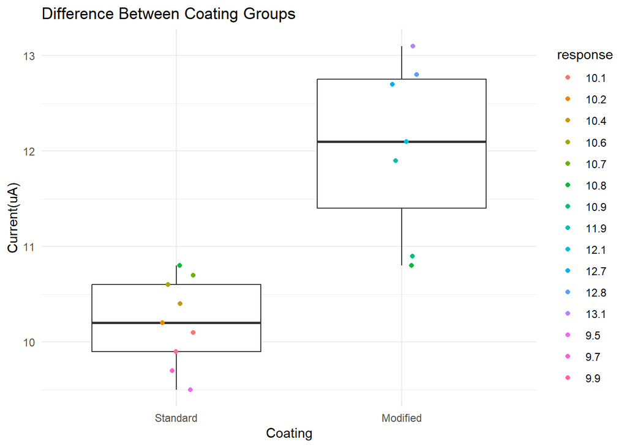

```r
final_data$coating <- fct_relevel(final_data$coating, "Standard", "Modified")

ggplot(data = final_data, aes(x= coating, y= as.numeric(response)))+
  geom_boxplot(outlier.shape = NA)+
  geom_jitter(width = 0.08, height = 0, aes(colour = response))+
  labs(title = "Difference Between Coating Groups", x= "Coating", y="Current(uA)")+
  theme_minimal()
```

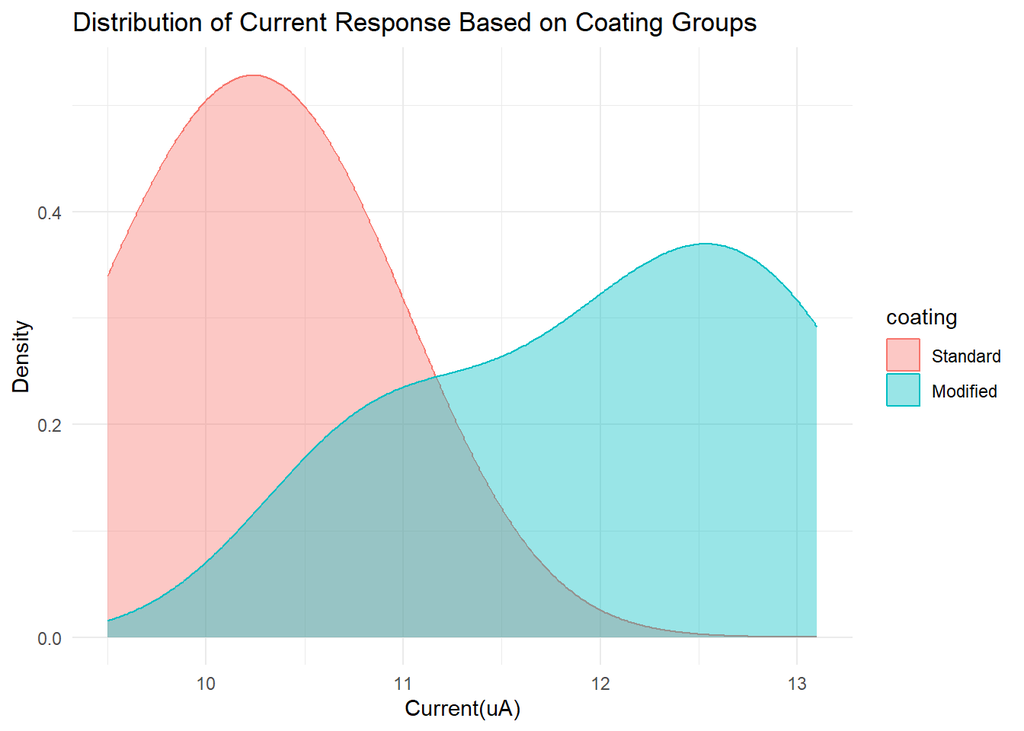

```r
ggplot(data = final_data, aes(x=as.numeric(response), colour = coating, fill = coating))+
  geom_density(bw = 0.6, alpha = 0.4)+
  labs(title = "Distribution of Current Response Based on Coating Groups", x= "Current(uA)", y="Density")+
  theme_minimal()
```

```r
aggregate(as.numeric(response) ~ coating, data = final_data, FUN = mean)
```

```
##    coating as.numeric(response)
## 1 Standard             10.21111
## 2 Modified             12.04286
```

```r
aggregate(as.numeric(response) ~ coating, data = final_data, FUN = sd)
```

```
##    coating as.numeric(response)
## 1 Standard            0.4539946
## 2 Modified            0.9126101
```

```r
write.csv(combination_data, "Combination Table.csv")
write.csv(clarification, "Clarification Table.csv")
write.csv(final_data, "Final Table.csv")
```

## Interpretation

Initial data frames had different number of electrode. Measurements had 26 electrode rows and it had two E011 and E099 differently. Electrodes had 25 electrode rows. All corrections and sortings were made and new combination data was created . All uncertain and missing values were not filled. Also, as I mentioned above there were 2 different current value for E011. Matching and proper electrodes were put together in final data and only included electrode as use status were added to final data; withdrawn and pending ones was excluded because of no approved electrode. In addition , Clarification data was generated for why some electrode had problems like missing or unknown value etc. The information needed to fill in the missing parts was as follows: Why did E011 have 2 different results? Why did the E099 electrode be on the list and what was its specifications? Additionally, it was necessary to access information in unknown, blank, missing, or question mark sections. In final , 2 different plot were plotted for visualization based on coating conditions. First box plot Showed that mean of standard group was lower than modified group and both group had low standard deviation especially distribution of standard group was closer. Other density plot showed general distribution. For standard group, density was seen at between at 10-10.5 uA and for modified group at between 12-12.5 uA. Also there was overlapped region. Even if a difference was observed, a definitive interpretation cannot be made due to incomplete information.

## Resources

1- https://www.youtube.com/watch?v=vAKs1-EEJ38 2- https://www.youtube.com/watch?v=YIpizY3QsKk 3- https://forum.posit.co/t/remove-spaces-for-values-in-a-column/71503 4- https://stackoverflow.com/questions/68526202/stringr-to-convert-first-letter-only-to-uppercase-in-dataframe 5- https://www.youtube.com/watch?v=x7ic1FN5Rjk 6- https://stackoverflow.com/questions/21243588/replace-blank-cells-with-character 7- https://www.r-bloggers.com/2017/07/useful-dplyr-functions-wexamples/ 8- https://www.reddit.com/r/RStudio/comments/1dthuw3/add_column_to_a_dataframe/ 9- https://www.r-bloggers.com/2024/11/how-to-compare-two-columns-in-r-a-comprehensive-guide-with-examples/ 10- https://www.youtube.com/watch?v=kg9Kgvv9-0g&list=PLtL57Fdbwb_D-iZXfWd2myjpYXSg_yi9G&index=9 11- https://www.youtube.com/watch?v=KnmDd9f8ASA 12- https://www.youtube.com/watch?v=uoqFm1Jyyvw&list=PLtL57Fdbwb_D-iZXfWd2myjpYXSg_yi9G&index=10 13- https://stackoverflow.com/questions/7641666/changing-text-in-a-data-frame 14- https://www.geeksforgeeks.org/r-language/forcats-package-in-r-programming/ 15- https://stackoverflow.com/questions/72943939/how-to-make-the-y-axis-value-in-order-when-using-ggplot2-in-r-language 16- https://stackoverflow.com/questions/16905425/find-duplicate-values-in-r 17- https://forum.posit.co/t/how-to-remove-rows-from-data-frame-whos-row-name-contains-a-specific-string/134339